# Practical Machine Learning Course Project

### Background

Wearable devices such as *Jawbone Up, Nike FuelBand, and Fitbit* allow to collect a large amount of data about personal activity. These type of devices are part of the quantified self movement – a group of enthusiasts who take measurements about themselves regularly to improve their health, to find patterns in their behavior, or because they are tech geeks.

In this project, the goal is to use data from accelerometers on the belt, forearm, arm, and dumbell of 6 participants and build a prediction model. The participants were asked to perform barbell lifts correctly and incorrectly in 5 different ways. More information is available from the website here: http://groupware.les.inf.puc-rio.br/har (see the section on the Weight Lifting Exercise Dataset).

The data for this project come from this source: http://groupware.les.inf.puc-rio.br/har. They have been very generous in allowing their data to be used for this kind of assignment.

### Data

The training data for this project are available here:

https://d396qusza40orc.cloudfront.net/predmachlearn/pml-training.csv

The test data are available here:

https://d396qusza40orc.cloudfront.net/predmachlearn/pml-testing.csv

### Model

```r
# load required libraries
library(caret)
library(doMC)
```

```r
registerDoMC(cores = 8)

train_URL <- "https://d396qusza40orc.cloudfront.net/predmachlearn/pml-training.csv"
test_URL <- "https://d396qusza40orc.cloudfront.net/predmachlearn/pml-testing.csv"
if (!file.exists("pml-training.csv")){
  download.file(train_URL, "pml-training.csv", method = "curl")
}
if (!file.exists("pml-testing.csv")){
  download.file(train_URL, "pml-testing.csv", method = "curl")
}
# list of incorrect values
rem.strings <- c("", "NA")
# re-read with na.strings
data <- read.table("pml-training.csv", header = TRUE, sep = ",", na.strings = rem.strings)
test.cases <- read.table("pml-testing.csv", header = TRUE, sep = ",", na.strings = rem.strings)
```

The dataset has 19622 observations with 160 features

```r
dim(data)
```

```
## [1] 19622   160
```

Summary of the data, not showed for brevity, shows a lot of features with missing data. Such feature should be removed. Imputing the missing data does not make sense in this case.

```r
# function to get a ratio of NA's
na.ratio <- function(x){
  total <- length(x)
  na.count <- sum(is.na(x))
  return((total - na.count) / total)
}
ratios <- apply(data, 2, na.ratio)
# dropping the columns with a large number of NAs
data <- data[ ,ratios > 0.9]
```

Futher data analysis shows that the first 7 features are related to indexing and time should be excluded from the dataset. It is a recommended practice to excluded such features from the model.

```r
# after reviewing the data the first 7 column are removed
data <- data[ , -(1:7)]
dim(data)
```

```
## [1] 19622    53
```

The prepared dataset has a significantly less features: 53.

The next step is to split the dataset into training and testing subsets.

```r
# partition data, 75% for training, 25% for testing
inTrain = createDataPartition(data$classe, p = 3/4, list = FALSE)
training = data[inTrain, ]
testing = data[-inTrain, ]
```

```r
# use cross validation to prevent over-fitting
control <- trainControl(method="cv", number = 5)
# train the model
model <- train(classe ~ ., data = training, method="rf",
                trControl = control, importance = TRUE, proximity = TRUE,
               allowParallel = TRUE)
```

```r
print(model)
```

```
## Random Forest
##
## 14718 samples
##    52 predictor
##     5 classes: 'A', 'B', 'C', 'D', 'E'
##
## No pre-processing
## Resampling: Cross-Validated (5 fold)
##
## Summary of sample sizes: 11775, 11774, 11773, 11775, 11775
##
## Resampling results across tuning parameters:
##
##   mtry  Accuracy   Kappa      Accuracy SD  Kappa SD
##    2    0.9910995  0.9887403  0.001110097  0.001404283
##   27    0.9918468  0.9896864  0.001247825  0.001578708
##   52    0.9848488  0.9808338  0.003079202  0.003892567
##
## Accuracy was used to select the optimal model using  the largest value.
## The final value used for the model was mtry = 27.
```

Number of variables available for splitting at each tree node in the final model is 27. This is also confirmed on the plot below:

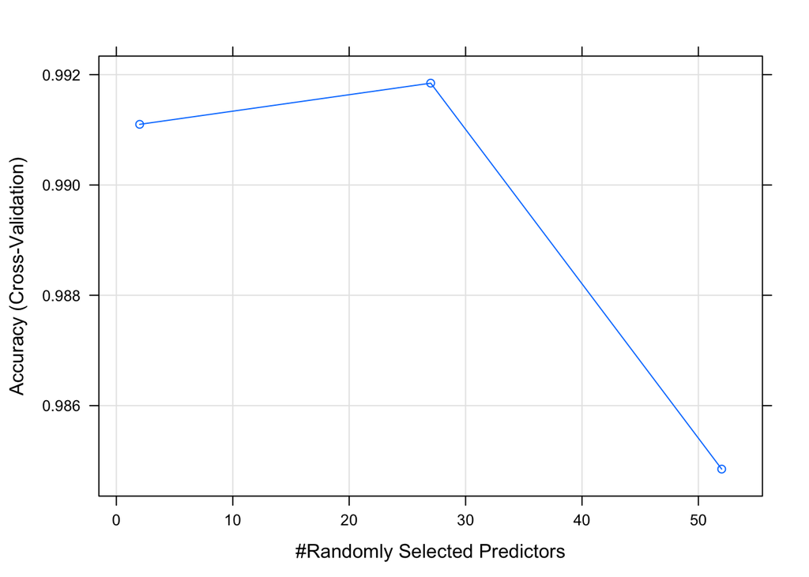

```r
library(ROCR)
plot(model)
```

Further investigation of the model to review the features importance.

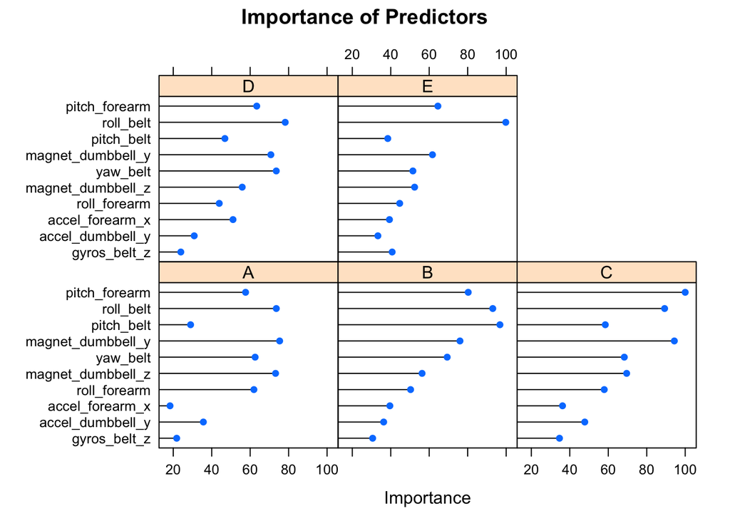

```r
varImp <- varImp(model)
plot(varImp, main = "Importance of Predictors", top = 10)
```

Next step is the model validation against previosly allocated for testing dataset

```r
prediction <- predict(model, testing)
confusionMatrix(prediction, testing$classe)
```

```
## Confusion Matrix and Statistics
##
##           Reference
## Prediction    A    B    C    D    E
##          A 1395    3    0    0    0
##          B    0  946    2    0    0
##          C    0    0  852    0    1
##          D    0    0    1  804    0
##          E    0    0    0    0  900
##
## Overall Statistics
##
##                Accuracy : 0.9986
##                  95% CI : (0.9971, 0.9994)
##     No Information Rate : 0.2845
##     P-Value [Acc > NIR] : < 2.2e-16
##
##                   Kappa : 0.9982
##  Mcnemar's Test P-Value : NA
##
## Statistics by Class:
##
##                      Class: A Class: B Class: C Class: D Class: E
## Sensitivity            1.0000   0.9968   0.9965   1.0000   0.9989
## Specificity            0.9991   0.9995   0.9998   0.9998   1.0000
## Pos Pred Value         0.9979   0.9979   0.9988   0.9988   1.0000
## Neg Pred Value         1.0000   0.9992   0.9993   1.0000   0.9998
## Prevalence             0.2845   0.1935   0.1743   0.1639   0.1837
## Detection Rate         0.2845   0.1929   0.1737   0.1639   0.1835
## Detection Prevalence   0.2851   0.1933   0.1739   0.1642   0.1835
## Balanced Accuracy      0.9996   0.9982   0.9981   0.9999   0.9994
```

The confusion matrix shows a quite impression accuracy making us to believe that the model would do well on unseen data.

### Submission

As part of this project the created model is used to predict the outcome for 20 cases. The result is stored in 20 files for automatic evaluation.

```r
# predict data for 20 test cases
test <- predict(model, newdata=test.cases)
# generate results into separate files
pm_write_files <- function(x){
    n  <- length(x)
    for(i in 1:n){
        filename <- paste0("problem_id_",i, ".txt")
        write.table(x[i], file = filename, quote = FALSE, row.names = FALSE, col.names = FALSE)
    }
}
pm_write_files(test)
```